# Sine Waves

Jeff Newmiller

27-AUG-2017

# Introduction

This is a rather skimming overview of some conceptual issues with sound and sound recording.

The code can play the sound waves if an appropriate command-line sound file player is installed. This was developed on Ubuntu 14.04/16.04, with the “play” sound player installed.

# Pure Sine Wave

Let’s make a sine wave sound object, one second long, 440Hz, 44100 samples per second:

```r
library(tuneR)
setWavPlayer( "play" ) # adjust if you have a different player
f1 <- 440 # Hz; fundamental frequency of example sine wave
fs <- 44100 # Hz, typical compact disk sample rate
wave1 <- sine( freq = f1
             , duration = 1
             , from = 0
             , samp.rate = fs
             , stereo = FALSE
             , xunit = "time"
             )
```

We can try to plot it:

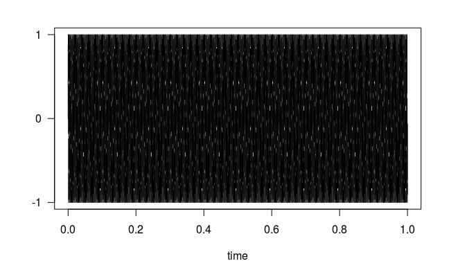

```r
plot(wave1)
```

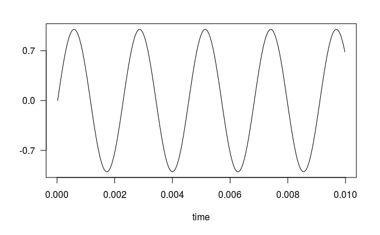

```r
plot( extractWave( wave1, from = 1, to = 440 ) )
```

Notice that the sine wave ranges from -1 to 1… this is standard for the mathematical sine wave function, but you need to realize that the computer speaker is connected to a digital-to-analog converter that has a maximum amplitude that isn’t “1” but is usually some number measured in volts or amps and the sound player software recognizes that and “stretches” the amplitude so that -1 to +1 corresponds to the limits of the D/A converter.

```r
play( wave1 )
```

[output not shown]

Lets see what happens when the sine wave has a smaller amplitude:

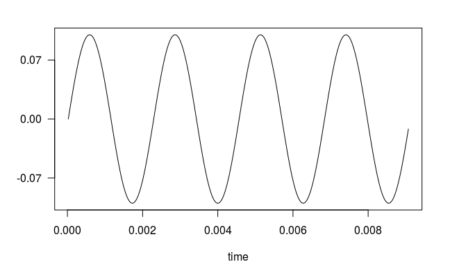

```r
wave2 <- wave1
wave2@left <- wave2@left / 10
plot( extractWave( wave2, from = 1, to = 400 ) )
```

The vertical size of the wave is one-tenth as big as it was. Listen:

```r
play( wave2 )
```

[output not shown]

Smaller amplitude means quieter!

What about a different sine wave frequency?

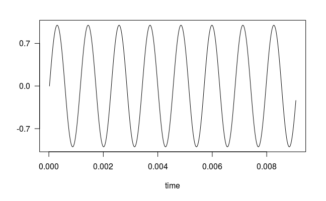

```r
f3 <- 880 # Hz
wave3 <- sine( freq = f3
             , duration = 1
             , from = 0
             , samp.rate = fs
             , stereo = FALSE
             , xunit = "time"
             )
plot( extractWave( wave3, from = 1, to = 400 ) )
```

More waves squeezed into the same time interval. Listen:

```r
play( wave3 )
```

[output not shown]

Frequency corresponds to pitch!

# 2 Serial Sine Waves

Can we make part of the wave at one frequency and the other part at a second frequency?

```r
wave4 <- bind( sine( freq = f1
                   , duration = 1
                   , from = 0
                   , samp.rate = fs
                   , stereo = FALSE
                   , xunit = "time"
                   )
             , sine( freq = f3
                   , duration = 1
                   , from = 0
                   , samp.rate = fs
                   , stereo = FALSE
                   , xunit = "time"
                   )
             )
show( wave4 )
```

```
Wave Object
    Number of Samples:      88200
    Duration (seconds):     2
    Samplingrate (Hertz):   44100
    Channels (Mono/Stereo): Mono
    PCM (integer format):   FALSE
    Bit (8/16/24/32/64):    32
```

Again, too many cycles up and down to see them individually, but can see the amplitude (1) and duration (1+1=2s):

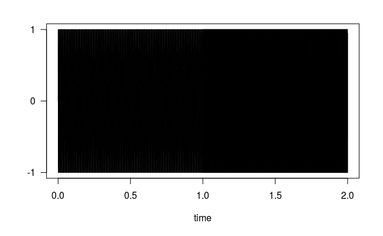

```r
plot( wave4 )
```

Looking just at the transition around 1 second:

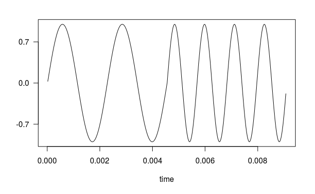

```r
tm4 <- ( 0:88200 ) * 1/44100
plot( extractWave( wave4, from = 43901, to = 44300 ) )
```

```r
play( wave4 )
```

[output not shown]

Notice that both frequencies have the same amplitude, but the higher frequency sounds louder. This is because the human ear is more receptive to frequencies closer to 3000Hz than higher or lower.

Since the frequency changes over time, lets look at the data in short intervals:

```r
pergm4 <- periodogram( wave4, width = 2048, taper = 0 )
pergm4
```

```
Wspec Object (use summary() for more details)

Number of Periodograms: 43
Estimated at 1024 Frequencies: 21.5332 ... 22050

Further parameters:
width:   2048
overlap: 0
normal.: TRUE
```

Setting the width to 2048 means that chunks of data 2048 points long (46.4399093 milliseconds) are pulled out and separately analyzed for frequency content. Here is what the first piece looks like:

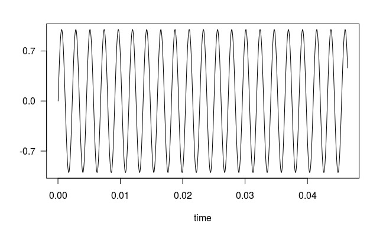

```r
plot( extractWave( wave4, from = 1, to = 2048 ) )
```

Notice that it doesn’t end up at the same level at the end as it started out (0), so if you imagine this piece repeating over and over indefinitely there would be little jumps every so often, like this:

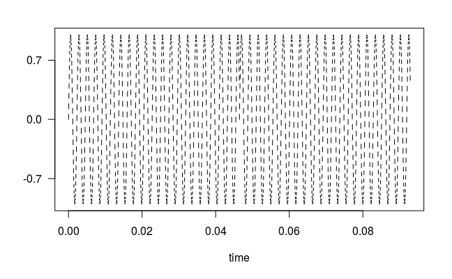

```r
wave4a <- extractWave( wave4, from = 1, to = 2048 )
wave4b <- bind( wave4a, wave4a )
plot( wave4b )
```

This imaginary jump in the short piece of waveform is what causes the peak to “spread out” with more frequencies:

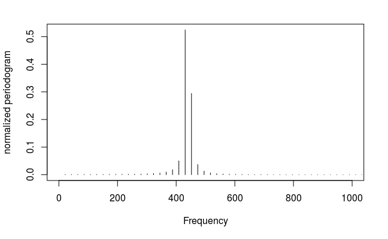

```r
plot( pergm4, xlim=c( 0, 1000 ), which = 1 )
```

Also notice that because the length of each chunk of data is fairly short, the information about the frequency content is spread out… in fact, the interval between extracted frequencies is $\Delta f = \frac{1}{T}$ where $T$ is the duration of the short burst of sound we extracted… $T$ is 46.4399093 milliseconds, so $\Delta f = 21.5332031 Hz$, which might seem kind of coarse. It is kind of coarse, but the trade-off is that now we can see how the frequency changes over time:

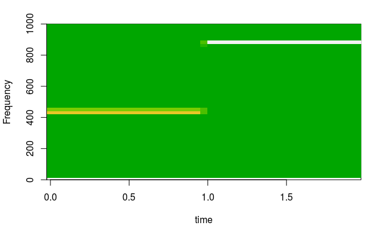

```r
image( pergm4, ylim = c( 0, 1000 ), xunit="time", col=terrain.colors( 12 ) )
```

In summary, there is a trade-off in how finely spaced the frequencies will be where you can estimate amplitude, and how finely spaced you can be in identifying the time at which changes occur. The longer the chunk of data used for examining frequency is, the more closely the frequency values are spaced, but the longer in time it will be between seeing changes.

The `tuneR` package helps you extract the largest amplitude frequencies from the spectrum:

```r
ff4 <- FF( pergm4 )
ff4
```

```
 [1] 438.7283 438.8545 439.0159 439.1058 439.0630 438.9169 438.7651 438.7061 438.7773
[10] 438.9334 439.0731 439.1025 439.0015 438.8387 438.7213 438.7245 438.8463 439.0085
[19] 439.1042 439.0684 438.9254 305.5266 881.2318 881.2094 881.1914 881.2173 881.2302
[28] 881.2017 881.1944 881.2244 881.2257 881.1955 881.2001 881.2295 881.2190 881.1918
[37] 881.2075 881.2317 881.2111 881.1911 881.2156 881.2308 881.2033
```

Each number represents the highest amplitude frequency for the corresponding block of 2048 data points. The 22nd block shifts frequencies abruptly, which confuses the algorithms and introduces the 306Hz estimate as the frequency shifts from 440Hz to 880Hz.

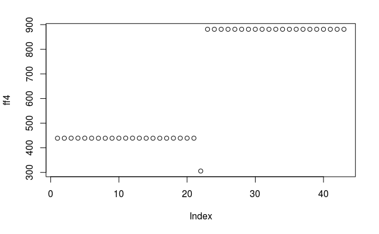

```r
plot( ff4 )
```

However, we can compare the found frequencies with musical note standard frequencies, where the tuning-fork A (440Hz) is 0, and one octave up is 12 half-steps up:

```r
nff4 <- noteFromFF( ff4 )
nff4
```

```
 [1]  0  0  0  0  0  0  0  0  0  0  0  0  0  0  0  0  0  0  0  0  0 -6 12 12 12 12 12 12
[29] 12 12 12 12 12 12 12 12 12 12 12 12 12 12 12
```

Finally, this function produces a plot that presents both notes played and loudness together. Notice the very narrow range of amplitudes represented in the “energy” band at the bottom, which makes the small variations look important. Also note that if more than one note is being played simultaneously (chords) this graph won’t show the quieter notes.

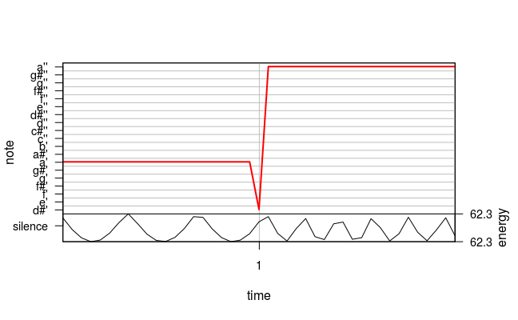

```r
melodyplot( pergm4, noteFromFF( FF( pergm4 ) ) )
```

# 2 Added (Mixed) Sine Waves

What if we try to play the sine waves at the same time?

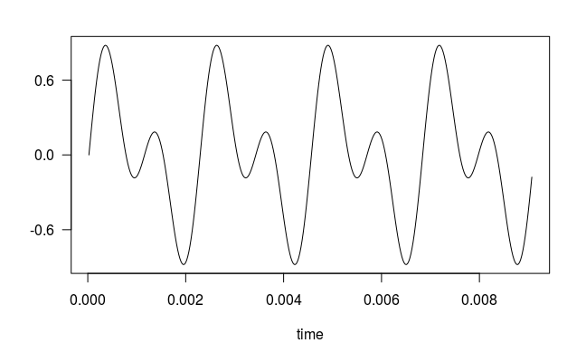

```r
wave5 <- ( sine(440)+sine(880) ) / 2
plot( extractWave( wave5, from = 1, to = 400 ) )
```

Each cycle is looking a bit lopsided, high at the beginning, low at the end.

```r
play( wave5 )
```

[output not shown]

For comparison, we plot the periodogram of the original plain amplitude=1 sine wave:

```
'width' must be a potence of 2, hence using the ceiling: 65536
```

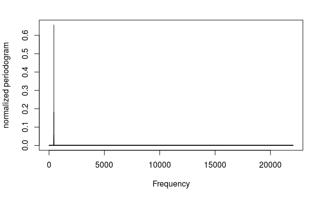

```r
plot( periodogram( wave1 ) )
```

The one spike in the frequency plot shows up at 440Hz for the `wave1` waveform.

```
'width' must be a potence of 2, hence using the ceiling: 65536
```

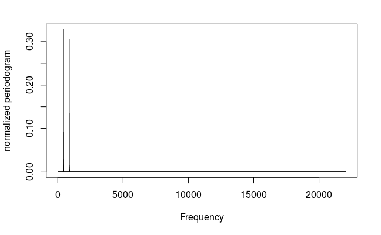

```r
plot( periodogram( wave5 ) )
```

For the `wave5` waveform, spikes appear at both 440Hz and 880Hz. Note that even though the two sine waves were generated with the equal magnitudes, the spikes in the periodogram are not equal due to numerical rounding error. Also, to keep the two waves from adding up to magnitudes greater than 1 each sine wave here has half the amplitude that it had in `wave1`. Fortunately we can see the important bit that the funny lopsided waveform was originally made up of two sine waves.

# A bunch of added sine waves

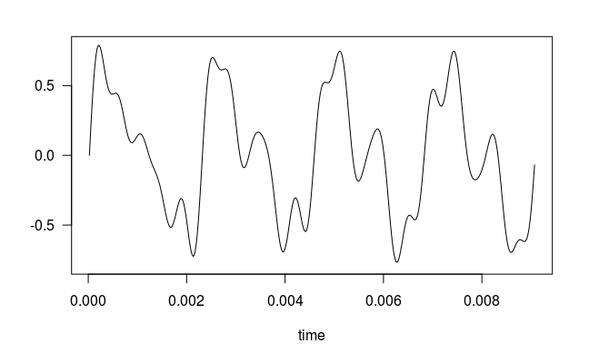

```r
wave6 <- (  sine( 440 ) + sine( 880 )/2 + sine( 1240 )/3 + sine( 1760 )/4 + sine( 2200 )/5 ) / 2
plot( extractWave( wave6, from = 1, to = 400 ) )
```

```
'width' must be a potence of 2, hence using the ceiling: 65536
```

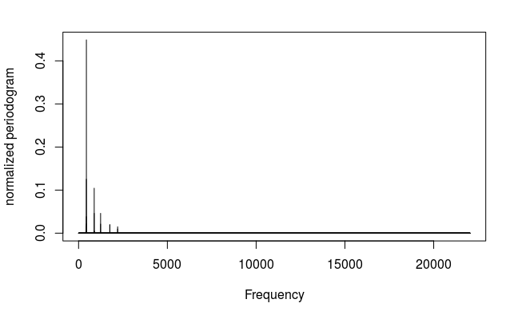

```r
plot( periodogram( wave6 ) )
```

It seems like we can combine sine waves to make quite a few different waveforms… in fact, an engineer named Fourier figured out in the nineteenth century that you could make any repeating waveform you wanted if you just added together enough sine waves.

```r
play( wave6 )
```

[output not shown]

# A triangle wave

So if any repeating waveform can be split up into many sine waves, what about a waveform made up of straight lines?

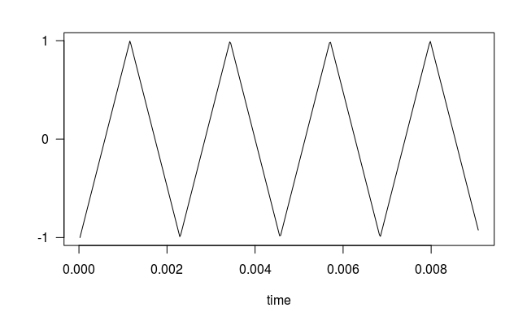

```r
tm3 <- ( 0:65535 ) / fs
wave7 <- Wave( 1 - abs( ( tm3 %% (1/f1) ) - 0.5 / f1 ) * 4 * f1
             , samp.rate = fs
             , bit = 32
             , pcm = FALSE
             )
plot( extractWave( wave7, from = 1, to = 400 ) )
```

If we look at it as frequencies:

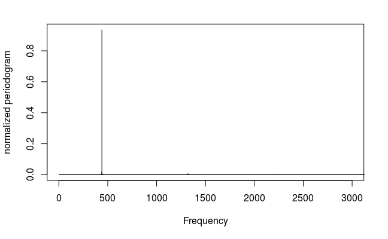

```r
plot( periodogram( wave7 ), xlim=c( 0, 3000 ) )
```

```r
x1 <- c( 0.1, 1, 10, 100, 1000 )
log10( x1 )
```

```
[1] -1  0  1  2  3
```

Basically the logarithm figures out what power you would have to take a base (10 in the above example) to in order to get the desired number. That is,

$$100 = 10^2 \rightarrow \log_{10}{100}=2$$

We know that 10 is closer to 1 than 100 is closer to 10, yet when we look at the logarithms we are comparing 1 to 0 and 2 compared to 1, which makes those differences seem like the same size.

If we apply the logarithm to the y-axis we can see what is happening to the small numbers more clearly:

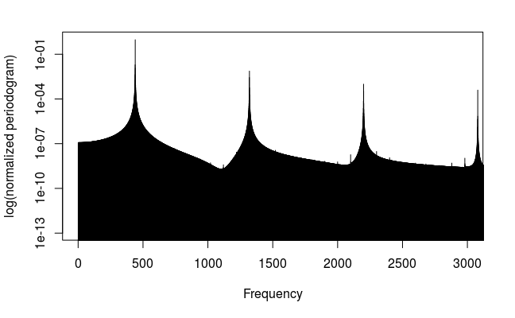

```r
pergm7 <- periodogram( wave7 )
plot( pergm7, xlim=c( 0, 3000 ), log="y" )
```

This graph is showing that not only are there sine waves with frequencies $f=440 \cdot (2n-1)$ being added together, but there are sine waves with frequencies in between. It turns out that a mathematical proof can show that the perfect triangle wave does not have those “in-between” sine waves, so this “noise” information appears because computers cannot represent an infinitely long sine wave and they cannot represent real numbers absolutely perfectly (always rounded off just a little).

```r
library(dplyr)
DF <- data.frame( freq = pergm7@freq
                , spec = pergm7@spec[[ 1 ]]
                )
DF <- arrange( DF, desc( spec ) )
head( DF, 12 )
```

|  | freq | spec |
| --- | --- | --- |
| 1 | 440.0848 | 0.9350420223 |
| 2 | 439.4119 | 0.0194835327 |
| 3 | 440.7578 | 0.0117073135 |
| 4 | 1320.2545 | 0.0074297429 |
| 5 | 438.7390 | 0.0042424947 |
| 6 | 441.4307 | 0.0032803926 |
| 7 | 1319.5816 | 0.0027373981 |
| 8 | 438.0661 | 0.0018058667 |
| 9 | 442.1036 | 0.0015155672 |
| 10 | 437.3932 | 0.0009950515 |

[output cut: 2 more lines]

```r
FF( pergm7 )
```

```
[1] 440.0363
```

Notice that the highest magnitude at 440Hz is 0.93 and at 1320Hz is 0.0074 (over 100 times smaller).

Lets listen to the sine wave and the triangle wave:

```r
wave7a <- bind( wave1, wave7 )
play( wave7a )
```

[output not shown]

The triangle wave sounds more… rich… (complicated?) because it actually has “overtones”. The exact mix of overtones in a waveform is what makes a guitar sound different than a trumpet or a cello. Nevertheless, even with all the extra overtones, the fundamental frequency can still be identified so we see below that both waveforms have the same basic pitch.

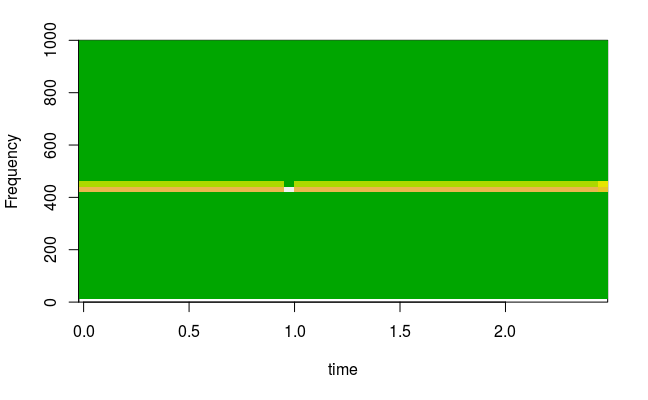

```r
pergm7a <- periodogram( wave7a, width = 2048 )
image( pergm7a, ylim = c( 0, 1000 ), xunit = "time", col=terrain.colors( 12 ) )
```

# Clipping

As mentioned above, a computer’s sound output has limits that it cannot exceed… if you try to put out a larger amplitude than it is capable of converting, it will “max out” the waveform (clip), creating a new waveform that sounds different (distorted) from the intended waveform.

## 50% Clip

If we double the amplitude:

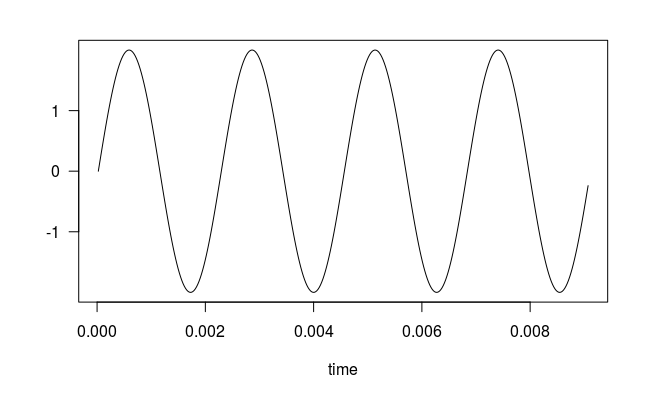

```r
wave8a <- wave1
wave8a@left <- wave8a@left * 2
plot( extractWave( wave8a, from = 1, to = 400 ) )
```

And then clip it off so it does not exceed a magnitude of 1:

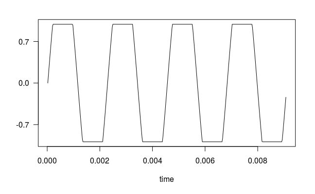

```r
wave8b <- wave8a
wave8b@left <- ifelse( 0.99 < abs( wave8a@left )
                     , 0.99 * sign( wave8a@left )
                     , wave8a@left
                     )
plot( extractWave( wave8b, from = 1, to = 400 ) )
```

```r
play( bind( wave1, wave8b ) )
```

[output not shown]

```r
pergm8b <- periodogram( wave8b )
```

```
'width' must be a potence of 2, hence using the ceiling: 65536
```

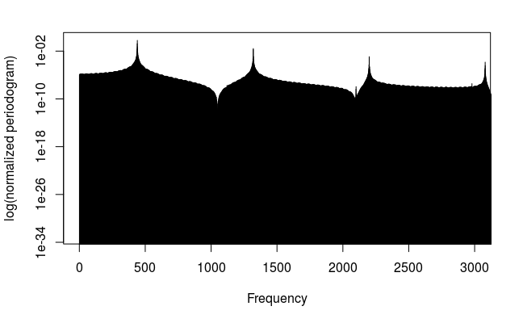

```r
plot( pergm8b, xlim = c( 0, 3000 ), log="y" )
```

```r
DF <- data.frame( freq = pergm8b@freq
                , spec = pergm8b@spec[[ 1 ]]
                )
DF <- arrange( DF, desc( spec ) )
head( DF, 12 )
```

|  | freq | spec |
| --- | --- | --- |
| 1 | 440.0848 | 0.622483967 |
| 2 | 439.4119 | 0.173178137 |
| 3 | 440.7578 | 0.053391923 |
| 4 | 441.4307 | 0.029956134 |
| 5 | 1320.2545 | 0.026769071 |
| 6 | 438.7390 | 0.021800024 |
| 7 | 1319.5816 | 0.017979442 |
| 8 | 437.3932 | 0.008544311 |
| 9 | 443.4494 | 0.005237423 |
| 10 | 436.7203 | 0.003596729 |

[output cut: 2 more lines]

For this waveform, the highest magnitude at 440Hz is 0.62, and at 1320Hz it is 0.026, a factor of about 20, so the overtones in this case are about 5 times larger (in a relative sense) than for the triangle wave.

## 25% Clip

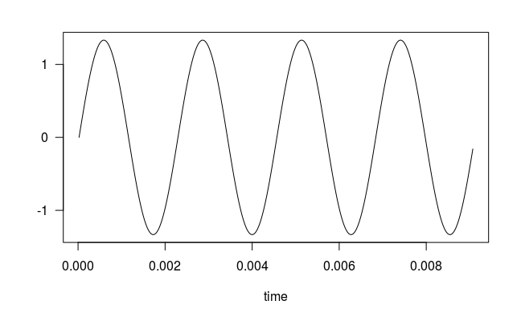

```r
wave9a <- wave1
wave9a@left <- wave9a@left * 4/3
plot( extractWave( wave9a, from = 1, to = 400 ) )
```

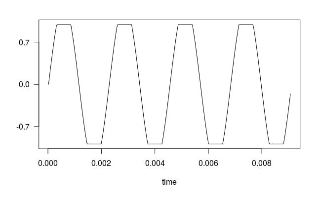

```r
wave9b <- wave9a
wave9b@left <- ifelse( 0.99 < abs( wave9a@left )
                     , 0.99 * sign( wave9a@left )
                     , wave9a@left
                     )
plot( extractWave( wave9b, from = 1, to = 400 ) )
```

```r
play( bind( wave1, wave9b ) )
```

[output not shown]

```r
pergm9b <- periodogram( wave9b )
```

```
'width' must be a potence of 2, hence using the ceiling: 65536
```

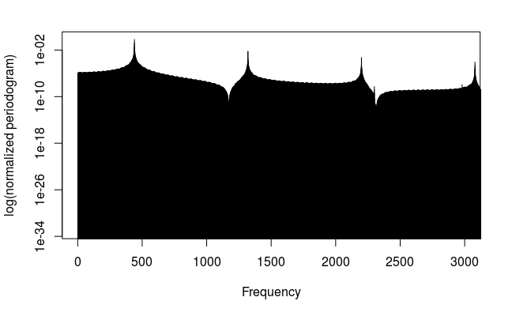

```r
plot( pergm9b, xlim = c( 0, 3000 ), log="y" )
```

```r
DF <- data.frame( freq = pergm9b@freq
                , spec = pergm9b@spec[[ 1 ]]
                )
DF <- arrange( DF, desc( spec ) )
head( DF, 12 )
```

|  | freq | spec |
| --- | --- | --- |
| 1 | 440.0848 | 0.648069467 |
| 2 | 439.4119 | 0.180235076 |
| 3 | 440.7578 | 0.055605337 |
| 4 | 441.4307 | 0.031208620 |
| 5 | 438.7390 | 0.022680700 |
| 6 | 437.3932 | 0.008883501 |
| 7 | 1320.2545 | 0.006655787 |
| 8 | 443.4494 | 0.005462009 |
| 9 | 1319.5816 | 0.004451047 |
| 10 | 436.7203 | 0.003738257 |

[output cut: 2 more lines]

Here the 440Hz fundamental is 0.65 and the second harmonic at 1320Hz is 0.0067, which, like the triangle wave is a ratio of about 100. That is, the harmonics are much smaller relative to the fundamental when clipping off 25% of the amplitude than when clipping off 50% of the amplitude.

# Guitar Sample 1

A couple of chords and single notes were recorded. We consider how they sound as recorded and with simulated clipping.

## As-is

```r
wave10 <- mono( readWave( "data/guitar1.wav" ), "left" )
play( wave10 )
```

[output not shown]

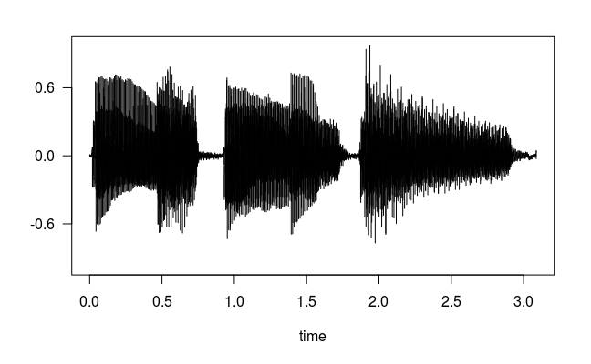

```r
plot( wave10 )
```

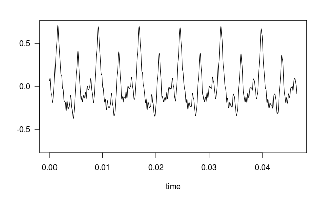

```r
plot( extractWave( wave10, from = 4 * 2048 + 1, to = 5 * 2048))
```

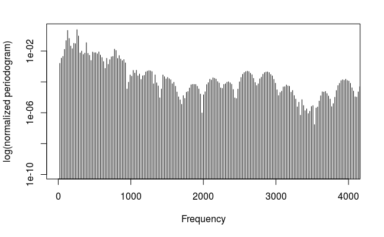

```r
pergm10 <- periodogram( wave10, width = 2048, overlap = 0.5 )
plot( pergm10, xlim = c( 0, 4000 ), log="y" )
```

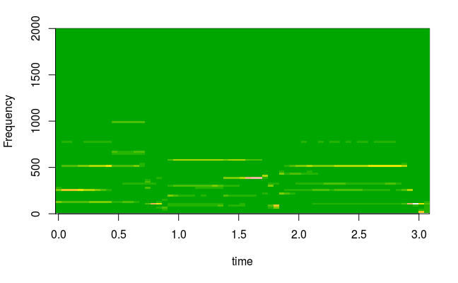

```r
image( pergm10, ylim = c( 0, 2000 ), xunit="time", col=terrain.colors( 12 ) )
```

```r
ff10 <- FF( pergm10 )
ff10
```

```
 [1] 135.11242 130.45227 130.41926 130.32453 130.15397 130.22201 128.14444 127.84623
 [9] 128.34809 130.11870 130.57504 130.05154 128.35436 130.50082 131.04231 122.50295
[17]        NA        NA        NA        NA 194.63733 192.60000 194.99132  96.82209
[25]  97.68160  97.54650  98.28538  98.91019  98.19322  94.06268 192.87175 194.65737
[33] 194.55120 192.43914 195.63195 193.07646 195.46281        NA        NA        NA
[41] 219.84755 219.44796 218.81335 109.86180 109.32075 110.02862 106.21835 106.05569
[49] 104.99041 108.88853 109.26293 105.15237 105.64386 109.11541 104.77592 105.49273
[57] 109.08258 104.82394 105.17431 109.67521 105.82607 105.03775 109.24094 105.21294
[65] 104.05239  26.51650 115.65268
```

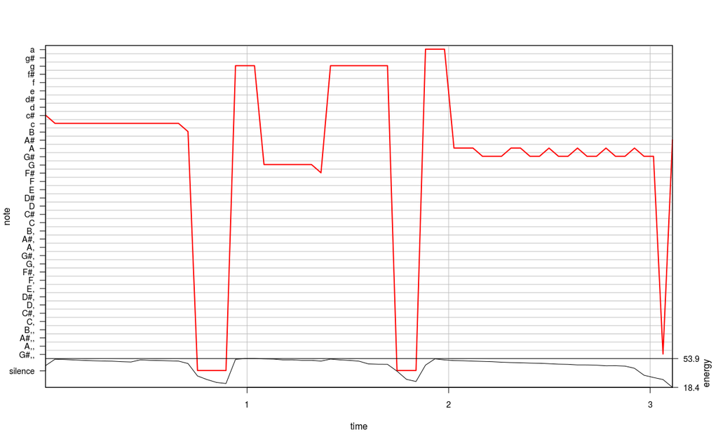

```r
nff10 <- noteFromFF( ff10 )
melodyplot( pergm10, nff10 )
```